# Graduate Fellows Handbook

New employee guide

Last compiled on March 16, 2022, Time: 21:38

### Table of contents

1. Welcome to the QCL
2. Dress code
3. Materials needed
4. New Employee Sign On  
   a.Before  
   b.After
5. Employee Materials
6. Accounts and Software
7. Logins and Passwords
8. Schedule
9. Graduate Fellows Meeting
10. Editing the QCL-CMC Website
11. Workshops  
    a.Start of Semester  
    b.Possible Workshops  
    c.Confirming Dates with Instructors  
    d.Worksflow
    - Two weeks before day of workshop
    - One week before day of workshop
      - Moderator
      - Zoom
      - Localist
    - Two days before day of workshop
    - Day before day of workshop
      - Qualtrics
      - Bit.ly
      - Flyer Word doc
      - Emails(to be written)
      - Reminder Email
      - Attendees Emails
    - Day of workshop
      - Moderator checklist
    - Day after workshop
      - Qualtrics
      - Zoom Recordings
      - Ending email example
    - Workshop Issues
5. Buying a ticket – Making sure it works
6. Changing Website
7. Checklist for a Typical Workday
8. Building a Workshop
   - Github
   - Pre-workshop requirements PDF
   - Presentation PDF
   - Files
9. Workshops Building
10. Zoom Recording Downloads
11. Qualtrics Make a Workflow
12. How to schedule meetings on Zoom
12. QCL Impact Report
1. Qualtrics – Reports
2. Localist – Reports
3. Summaries
   - Missing Data
   - Localist
   - Qualtrics
4. Rough Draft Impact Report

### 1. Welcome to the QCL

Paragraph about QCL

Mission Statement

### 2. Dress code

Office Casual

### 3. Materials needed

- Computer

### 4. New Employee Sign On

#### a. Before

- Resume and Cover Letter and References
- Interview
- Acceptance

#### b. After

- HR email
  - Orientation
  - Workday
    - IT will send you an email
    - https://www.myworkday.com/theclaremontcolleges/d/home.htmld
  - Signed documents
  - Show U.S. Citizenship/VISA
  - Get temporary permit for parking
    - Park in CMC permit parking or on the street (no permit needed)(map on page 4)
- Talk about Schedule
- Shadow a workshop
- Employee Materials (Next page)
- Download Software (Next page)
- Make Accounts (Next page)

[figure not shown]

Claremont Campus Map

### 5. Employee Materials

- Employee ID
  - Go to Connects in The Claremont Colleges Library Honnold Mudd (H on map, page 4)
    - Take picture
    - Receive ID
  - Go to Story House (14 on map, page 4)
    - Get access to infrastructure (doors)
    - Also need a KEY for office room
- Email and Username
  - Setup appointment for IT (Jeff)
    - Jeffrey.Ng@claremontmckenna.edu (jng@cmc.edu) or help@cmc.edu
  - Obtain computer access
  - Get put into system
- Kronos
  - Send email to Payroll
    - payroll@cmc.edu
  - Find Kronos in Workday
  - Log in hours
    - Talk to Janna
- Health Documents
  - https://www.cmc.edu/healthscreen
- Training with EVERFI
  - Hazard Communication (CA)
  - Protecting Youth
  - Preventing Harassment and Discrimination: Non-Supervisors
  - Injury & Illness Prevention
  - Data Security and Privacy

### 6. Accounts and Software

- CMC Self-Service Account Management
  - https://mypassword.claremontmckenna.edu/showLogin.cc
- CMC Email
  - https://cmc.edu/mail/office365
    - CMC e-mail address: firstname.lastname@claremontmckenna.edu
    - Short-hand: firstthreelettersofyourfirstnameandwholelastname@cmc.edu
- Dashboards Events
  - https://events.cmc.edu/newemployeeusername/home
- GitHub
  - https://github.com/CMC-QCL
- Workday
  - https://www.myworkday.com/theclaremontcolleges/d/home.htmld (refer to page 3)
  - Kronos (in here)
- QCL Home page
  - cmc.edu/login
  - https://www.cmc.edu/qcl
- Box
  - https://claremontmckenna.account.box.com/login?redirect_url=%2Ffolder%2F0
- Bit.ly
  - No account (you will use it a lot)
  - https://bitly.com/
- Qualtrics
  - https://qfreeaccountssjc1.az1.qualtrics.com/login?path=%2FQ%2FMyProjectsSection&product=project-store-proxy
- Localist
  - https://events.cmc.edu/admin
- Zoom
  - https://cmc-its.zoom.us
- Teams
  - Make sure to download desktop version and mobile as well
  - https://teams.microsoft.com
- Instagram
  - https://www.instagram.com/cmc.qcl/

*Issues: contact another Graduate Fellow or IT (help@cmc.edu)*

### 7. Logins and Passwords

| Accounts | Username | Password |
| --- | --- | --- |
| CMC Self-Service Account Management |  |  |
| CMC Email |  |  |
| Dashboards Events |  |  |
| GitHub |  |  |
| Workday |  |  |
| QCL Home page |  |  |
| Box |  |  |
| Bit.ly |  |  |
| Qualtrics |  |  |
| Localist |  |  |
| Zoom |  |  |
| Teams |  |  |
| Instagram |  |  |

*Firefox: bookmark websites*

### 8. Schedule

**Important Dates**

- Team meetings
  - Biweekly: Wednesdays 10am -11am
- Graduate Fellow meetings
  - Talk to Dr. Park to set up best time
  - Current Fellow meeting: 9:30am-10am
  - New Time: _______________________
- Workshops
  - Wednesdays 3pm-5pm or 4pm-6pm
  - Fridays 9am-11am or 10am-12pm
- Staff days
  - Janna will send out email
- Employees Schedule (20 hours a week)
  - Talk to Dr. Park

[output not shown]

*Days off: Holidays and Academic break*

### 9. Graduate Fellows Meeting

- BOX
  - Titled: QCL Fellows Meeting Agenda
  - https://claremontmckenna.app.box.com/folder/0

[figure not shown]

QCL Fellows Meeting Agenda

- Agenda
  - Write meeting notes
    - Before meeting
      - Let Dr. Park write minutes unless he asks you
  - Follow along in the meeting
  - TO DOs
    - Your assignments for the week

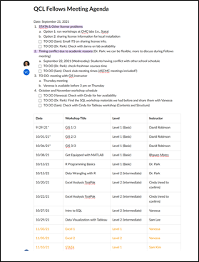

Your assignments for the week

### 10. Editing the QCL-CMC Website

Every week, we update cmc.edu/qcl/qcl-workshop page, whenever we open or close registration + update our schedule

In terms of website access:

1. Log in at cmc.edu/login
2. Go to cmc.edu/qcl
3. See “View,” “Edit,” and “Revisions” tabs right above body

[figure not shown]

website access

### 11. Workshops

#### a. Start of Semester

- Topics
  - Pick
  - Dr. Park in Fellows meeting
- Dates
  - Assign
  - Dr. Park in Fellows meeting
- Instructors
  - Assign
  - Dr. Park in Fellows meeting

#### b. Possible Workshops

- Dr. Park
  - R Programming Basics (level 1)
  - Data Wrangling with R (level 2)
  - Tableau (level 1)
- Bhaven
  - Get Equipped with LaTeX (level 1)
  - Get Equipped with MATLAB (level 1)
- Vanessa
  - Excel (level 1)
  - SQL (level 1) (Find cloud based complier that imports files like csv and sql)
  - GIS (level 1) (ArcGIS Online for Mac and Windows)
- Sam Kim
  - STATA (level 1)
  - STATA (level 2) – develop with Sam Lee
- Others (need instructors)
  - Julia = Alfonso Landeros alanderos@ucla.edu
  - XSEDE
  - Bash = Brad McCauley bmccauley@hmc.edu
  - Unix Shell and Git = Jeanine Finn jeanine.finn@claremont.edu
  - MS Power Automate as Pre to Power BI = Cindy Cheng cindy.cheng@cgu.edu
  - MS Power Query as Pre to Power BI = Cindy Cheng cindy.cheng@cgu.edu
  - Alteryx = Brandon Bak brandonbak@gmail.com
  - Machine Learning = Aashita Kesarwani akesarwani@hmc.edu
  - Python
  - Power BI = Jillian Seymour

#### c. Confirming Dates with Instructors

Subject: QCL Workshops - confirming dates

Good afternoon Bhaven,

Happy Tuesday! I hope you are doing well! As the new semester approaches, I wanted to confirm if these dates work for you to instruct:

Monday, January 24, 2022, at 5pm - 7pm for Get Equipped with LaTeX as an online workshop

Monday, February 21, 2022, at 5pm - 7pm for Get Equipped with MATLAB (TBA as a hybrid, in-person, or online workshop due to the Covid policies)

We have only scheduled up to Spring Break, I will have to follow up in the future for the rest of the semester’s dates. Do these dates and time work for you to instruct the workshops?

Thank you,  
Vanessa Arias Casillas  
Graduate Fellow - Murty Sunak Quantitative and Computing Lab (QCL)  
Claremont Mckenna College  
vanessa.casillas@claremontmckenna.edu

#### Two weeks before day of workshop

- Contact Instructor
- Setup meeting
  - Agenda of meeting
  - Summary of localist
  - Software
  - Websites
  - Licenses

*Instructors Notes turned into Summaries*

Good afternoon [instructor’s name],

Happy Tuesday! I am looking forward to your dryrun of [workshop]! I am starting to create the registration page for the workshop and would like to get a bit of information from you about the workshop.

First, do you have a summary page for your workshop? I have an example of Sam Lee’s below:

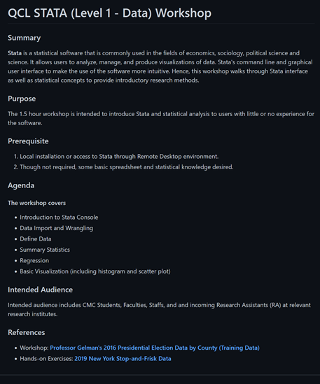

example of Sam Lee’s

Second, do you have any pre-workshop requirements that the attendees need to do before the workshop? Like download programs or sign up for a license.  
Third, what time did you want to do your workshop at 3pm-5pm or 4pm-6pm?  
Fourth, would you like this workshop to be a hybrid, online only or in-person only?  
Lastly, is there any information you would like me to let the attendees know about before walking into the workshop? like website where to download files or a note about the data.  
Thank you for this information, it will help me in getting the workshop’s registration ready.

Thank you,  
Graduate Fellow - Murty Sunak Quantitative and Computing Lab (QCL)

*[QCL Workshop] Title*

About this Event  
Title  
Summary  
Agenda:  
Learning Objectives: (You will learn how to)  
Prerequisite:  
Location:  
Participants:

*Example Instructors Notes turned into Summaries*

*[QCL Workshop] R Programming Basics (Level 1 – Coding)*

About this Event

R Programming Basics (Level 1 - Coding)

Summary:  
R is an open-source statistical programming language. R is widely used in industry as well as in academia for statistical analysis and data visualization. In this workshop, we introduce the basics of the R language and its programming environment through simple hands-on examples. This workshop is designed for beginners in R programming, so no prior knowledge of R programming is needed. However, general programming knowledge in any programming language will be help understand the programming concepts. We will be using RStudio Cloud for hands-on. Please create a free account at https://rstudio.cloud before join the workshop.

Agenda:  
• Basics of R and RStudio • R Programming Environment: Workspace, Working Directory, Package • R objects (data structure and function) • R packages for data import and export • R graphics for simple plotting methods • Basic statistical analysis using R

Location:  
Hybrid (In-person: QCL Classroom, Online: Zoom information will be provided to the attendees after registration) Click here to find your way to the QCL.

Participants:  
CMC Students, Faculty, and Staff  
___

*Data Wrangling with R (Level 2 - Data)*

Summary:  
Data wrangling is the process of obtaining, cleaning, reshaping, and transforming raw (and messy) data into a useable form of processed (and tidy) data. It is known that a majority of data analysts and data scientists spend as much as 80% of their time on data wrangling. So it’s essential to get familiar with good data wrangling tools that help you save time and avoid errors. In this hands-on workshop, you will learn basic skills to import, export, clean, reshape, transform, and visualize data using well-known data science package called tidyverse.

Learning Objectives: (You will learn how to)  
Import and export data Clean, reshape and transform data Make messy data into tidy data Visualize tidy data using ggplot2 (if time permits)

Prerequisites:  
Basic knowledge of R and RStudio (e.g., R Programming for Beginners - Level 1) RStudio Cloud account; if you don’t have one yet, please create a new account from https://rstudio.cloud site. Tidyverse package; please make sure that you have installed the tidyverse package in your R environment. See https://www.tidyverse.org for more information.

Location:  
Hybrid (In-person: QCL Classroom, Online: Zoom information will be provided to the attendees after registration) Click here to find your way to the QCL.

Participants:  
CMC Students, Faculty, and Staff  
___

*GIS - Part 2 (Level 1 - Data) Workshop*

About this Event

Summary:  
This workshop will introduce you to the ever-expanding and fascinating world of geographic information systems (GIS). In three 2-hour sessions you will learn about what GIS is, how it is used in a multitude of industries and fields, and how to get started using GIS software. We will examine GIS concepts and software tools used to visualize real-world features, discover patterns, and communicate information. Primarily using ArcGIS Online (if you can hyperlink: https://doc.arcgis.com/en/arcgis-online/get-started/what-is-agol.htm) you will work with GIS maps, explore data, and analyze maps and data as you learn fundamental concepts that underlie GIS technology. Through a series of presentations, in-class tutorials, and homework assignments this workshop will give you a strong beginning foundation on how to make maps and explore spatial data to identify patterns and insights in your data you never knew possible. You will come away from this workshop with the understanding you need to start working with GIS and utilize it in your own work and explorations. You do not need any previous experience – just your own curiosity! Students in this workshop (in fact, all Claremont Colleges students) have free access to a wide variety Esri GIS products. For more information, check out the Claremont Colleges Library Geographic Information System (GIS) Services home page, https://library.claremont.edu/gis/

Learning Objectives: (You will learn how to)  
Topics will include: • Introduction to the GIS Platform • Theoretical basis of GIS and the Geographic Approach • What can you do with GIS? • Understanding GIS data • An introduction to Coordinate systems and Projections • Acquiring and selecting GIS Data • Utilizing and preparing your own data for GIS • Creating maps – basic cartography, symbology • The US Census and GIS • Introductory Spatial Analysis • Sharing results – physical maps and the world online maps

Location:  
The following event will be conducted in a hybrid format: • Virtual: Zoom • In-Person: QCL Classroom

Participants:  
7C Students, Faculty and Staff  
___

#### One week before day of workshop

**Moderator**

- If you are instructing
  - Ask for whoever moderator a week before or instruct and moderate yourself.

**Zoom**

Step 1:

- Go to meetings

[figure not shown]

Step 2:

- Click on Schedule

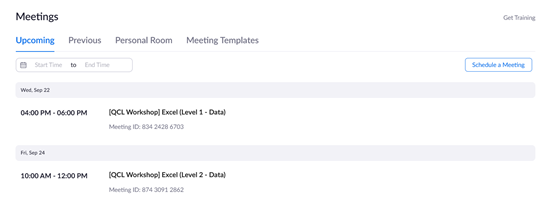

Step 3:

- Go to QCL workshop

[figure not shown]

Step 4:

- Look for workshop you are working

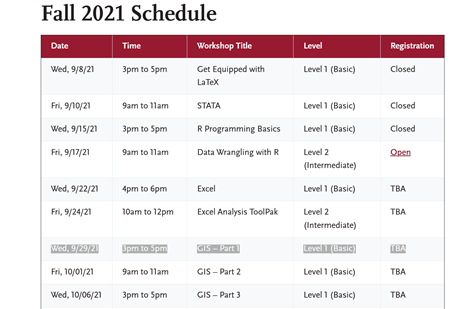

Step 5:

- Fill in meeting information on Zoom then click save,
  - Description (Optional) comes from Instructor’s meeting

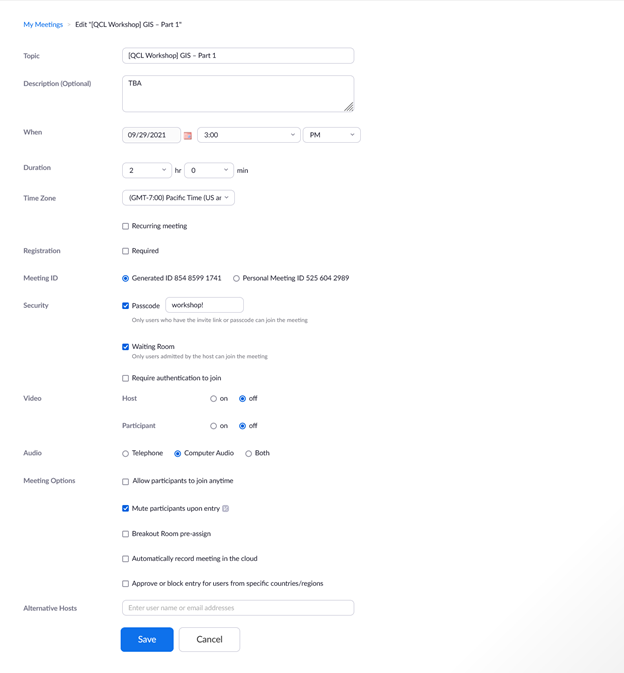

Step 6:

- You will see this

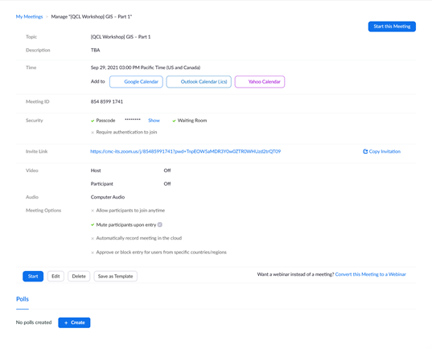

Step 7:

- On meeting tab, it should there

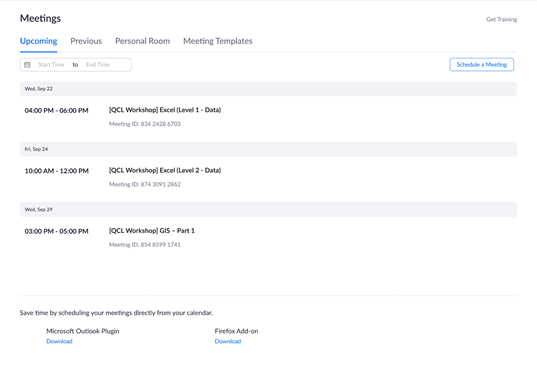

**Localist**

Step 1:

- Start by copying an old event
  - Make sure you are working on copy
- Fill in all information (Like below)
  - Click “Include Above in Schedule”
  - Delete the old Confirmed dates
  - Description is made from Instructor’s meeting

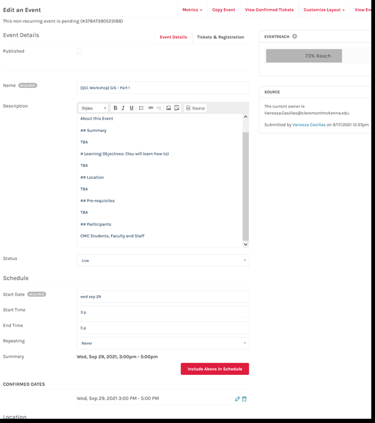

Step 2:

- Fill out Location (Like below)
  - Check if event is only in-person, only virtual or hybrid

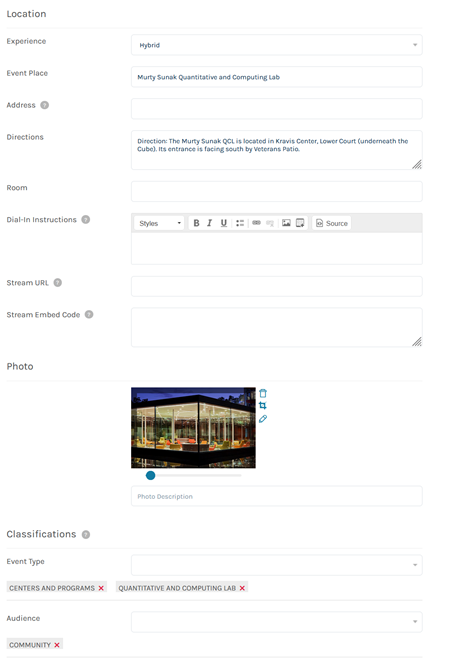

Step 3:

- Change the Owner to yourself
  - Check Vanity URL (qcl_workshop_stata_fa21_1117)

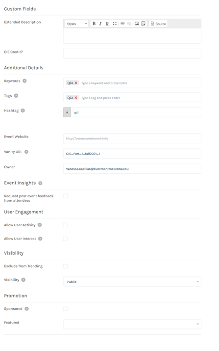

Step 4:

- Add a Ticket Types
  - Virtual or In-Person (or both)
  - Make sure Virtual is always on Top

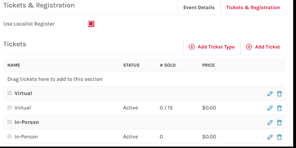

Step 5:

- Add a Virtual ticket name is ZOOM and drag to the right ticket type (pic wrong)
  - Then go into additional ticket options

[figure not shown]

Step 6:

- Check to make sure settings are correct
  - Make sure Ticket availability dates correctly dated or left blank if you will manual turn off

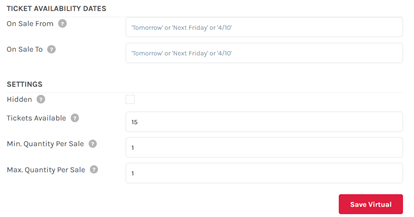

Step 7:

- Add in-person ticket named QCL CLASSROOM and drag to the right ticket type (pic wrong)
  - Then go into additional ticket options

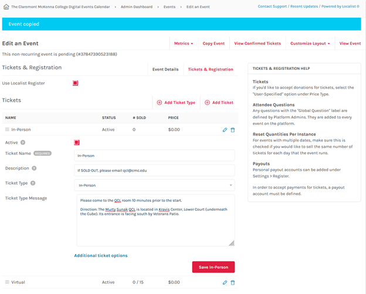

Step 8:

- Check to make sure setting are correct

[figure not shown]

Step 9:

- Check to make sure that Attendees Questions are correct
1. “Please enter your student ID # (Must be 8 characters). For all faculty/staff/non-Claremont Colleges person, please insert 00000000.” (Required)
2. “Please indicate gender (male or female)”
3. “Which one of the Claremont Colleges are you from?” (Required)
4. “If not from the Claremont Colleges, where are you from?”
5. “Are you a Freshman, Sophomore, Junior, Senior, Graduate Student, Faculty, Staff or Other?” (Required)
6. “If Other, please specify:”

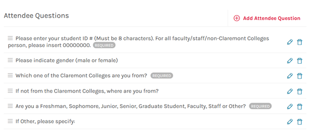

Step 10:

- Check to make sure you have the correct Event Capacity

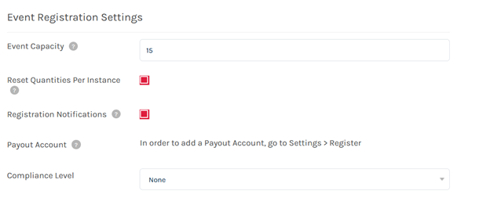

Step 11:

- Publish or NOT
  - Make sure if you are publishing that the checkmark is checked
  - But if you want another Fellow to review then make sure publish is not checked
  - Then Click Save
- TEST! TEST! TEST!
  - when you set up the registration pages, please test them by registering for the workshops and see if everything works fine including the email confirmation, Zoom links, etc.
- Send Dr. Park an email + post a message on Teams so that I can announce them.

[figure not shown]

#### Two days before day of workshop

*Close Registration for workshop*

Step 1:

- For those that do not require extensive prior prep, let’s close them 5 pm a day before. And, 2 days prior for those that require requesting licenses
  - Go into event
  - Go into tickets
  - Click inactivate on any tickets that are active

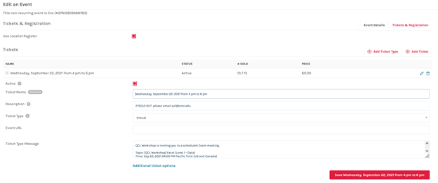

Step 2:

- You should see the ticket status as inactivate

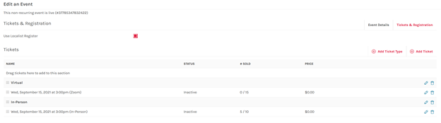

#### Day before day of workshop

**Qualtrics**

Step 1:

- Make sure to make a Sign and Exit one
  - Make copy of old one
  - Sign in for sign in (Fall_2021_Signin_Survey_SQL_Lvl1_Vanessa_Casillas_1119)
  - Exit for Exit (Fall_2021_Exit_Survey_SQL_Lvl1_Vanessa_Casillas_1119)

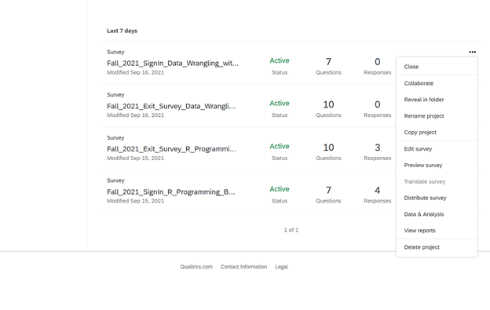

Step 2:

- Change name to workshop name and instructor

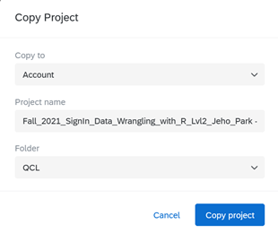

Step 3:

- Change workshop sign-in for and Date/Time
  - Sign-in

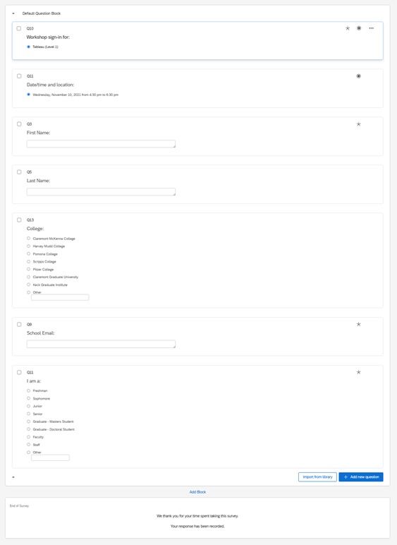

Step 4:

- Change workflow link
  - In email to the weird code
  - Make sure Dr. Park is getting an email sent to him

[figure not shown]

[figure not shown]